# Precios Hedonicos

Jorge Martelo

1/6/2021

Diferentes estudios que incorporan metodologias de precios hedonicos han supuesto que el valor asignado por un consumidor de una amenidad/desamenidad sin valor de mercado es constante a través del tiempo, sin embargo, ciertos factores generan un proceso de ajuste y cambios en la valoracion y disponibilidad a pagar de los afectados. El ejercicio a continuacion muestra los datos sobre las ventas de casas mono familiares en el norte de Andover - Massachussets, para los años de 1978 y 1981. La idea es la de evaluar el impacto que tiene la construccion de un incinerador de basuras al noroccidente del pueblo. El proceso de construccion del inciderador surtio diferentes etapas:

- **1974 - 1978: Pre rumor**
- 1979 - 1980: Rumor
- **1981 - 1984: Construccion**
- 1985 - 1988: Online
- 1989 - 1992: Operacion

La primera mencion sobre la posibilidad de la construccion del incinerador se dio a finales de 1978, sin embargo, dado que toma cierto tiempo la propagacion de informacion entre los habitantes, este periodo se tomara como si no se hubiese conocido nada sobre la posibilidad de la construccion.

Dentro de la data se considera el perioro de 1981 debido a que se da fin a todos los rumores y se procede a la construccion de la planta. En los periodos anteriores existe cierta incertidumbre por parte de la poblacion sobre la construccion del incinerador, sin embargo en 1981 se da a entender a la poblacion que el proyecto ya es una realidad.

La descripcion de las variables se muestra a continuacion:

- year: Fase del proceso de creacion de incinerador
- age: Antiguedad de la vivienda
- cbd: Distancia del hogar hasta el distrito central de negocios.
- intst: Distancia del hogar a la entrada el estado en pies
- rooms: Numero de habitaciones
- area: Area construida en metros cuadrados
- land: Area del lote en metros cuadrados
- baths: Numero de baños
- dist: distancia hasta el incinerador en pies
- wind: nivel del viento
- rprice: Precio de venta de la vivienda idexado

#### 1. cargar la base de datos

```r
library(readxl)
PH <- as.data.frame(read_excel("C:/Users/marteloa.5/Google Drive/Teleperformance/Sesiones de R/Precios Hedonicos/KIELMC_2.xls"))
```

#### 2.Revisar la estructura interna de los datos. En caso de que una variable no tenga el tipo requerido, cambiarlo

```r
str(PH)
```

```
## 'data.frame':    321 obs. of  11 variables:
##  $ year  : num  1978 1978 1978 1978 1978 ...
##  $ age   : num  78 1 1 1 0 12 12 9 189 25 ...
##  $ cbd   : num  10000 14000 14000 14000 11000 8000 11000 11000 14000 7000 ...
##  $ intst : num  10000 16000 16000 16000 12000 8000 13000 13000 17000 7000 ...
##  $ rooms : num  5 7 7 9 7 7 7 6 9 6 ...
##  $ area  : num  990 2781 2796 2794 3770 ...
##  $ land  : num  1710 43560 43560 43995 282704 ...
##  $ baths : num  1 3 3 3 3 3 3 3 4 2 ...
##  $ dist  : num  15600 15600 15600 15600 15500 15000 15000 14800 14500 14000 ...
##  $ wind  : num  5 11 11 11 7 5 7 7 11 5 ...
##  $ rprice: num  34000 148000 90400 125000 300000 ...
```

#### 3. Realizar un resumen estadistico de las variables a nivel general y por etapa. Que variables presentan comportamientos distintos?

```r
# Descriptivo general
summary(PH)
```

```
##       year           age              cbd            intst
##  Min.   :1978   Min.   :  0.00   Min.   : 1000   Min.   : 1000
##  1st Qu.:1978   1st Qu.:  0.00   1st Qu.: 9000   1st Qu.: 9000
##  Median :1978   Median :  4.00   Median :14000   Median :16000
##  Mean   :1979   Mean   : 18.01   Mean   :15822   Mean   :16442
##  3rd Qu.:1981   3rd Qu.: 22.00   3rd Qu.:23000   3rd Qu.:24000
##  Max.   :1981   Max.   :189.00   Max.   :35000   Max.   :34000
##      rooms             area           land            baths
##  Min.   : 4.000   Min.   : 735   Min.   :  1710   Min.   :1.00
##  1st Qu.: 6.000   1st Qu.:1560   1st Qu.: 16935   1st Qu.:2.00
##  Median : 7.000   Median :2056   Median : 43560   Median :2.00
##  Mean   : 6.586   Mean   :2107   Mean   : 39630   Mean   :2.34
##  3rd Qu.: 7.000   3rd Qu.:2544   3rd Qu.: 46100   3rd Qu.:3.00
##  Max.   :10.000   Max.   :5136   Max.   :544500   Max.   :4.00
##       dist            wind            rprice
##  Min.   : 5000   Min.   : 3.000   Min.   : 26000
##  1st Qu.:13400   1st Qu.: 5.000   1st Qu.: 59000
##  Median :19900   Median : 7.000   Median : 82000
##  Mean   :20716   Mean   : 6.978   Mean   : 83721
##  3rd Qu.:27200   3rd Qu.:11.000   3rd Qu.:100230
##  Max.   :40000   Max.   :11.000   Max.   :300000
```

```r
# Descriptivo por etapa 1
library(dplyr)
PH %>%
  filter(year == 1978) %>%
  summary()
```

```
##       year           age              cbd            intst
##  Min.   :1978   Min.   :  0.00   Min.   : 1000   Min.   : 1000
##  1st Qu.:1978   1st Qu.:  0.00   1st Qu.: 7000   1st Qu.: 7500
##  Median :1978   Median :  5.00   Median :17000   Median :17000
##  Mean   :1978   Mean   : 21.21   Mean   :16425   Mean   :17128
##  3rd Qu.:1978   3rd Qu.: 23.00   3rd Qu.:24000   3rd Qu.:26000
##  Max.   :1978   Max.   :189.00   Max.   :35000   Max.   :34000
##      rooms             area           land            baths
##  Min.   : 4.000   Min.   : 750   Min.   :  1710   Min.   :1.000
##  1st Qu.: 6.000   1st Qu.:1495   1st Qu.: 15548   1st Qu.:2.000
##  Median : 7.000   Median :1998   Median : 43663   Median :2.000
##  Mean   : 6.581   Mean   :2000   Mean   : 42956   Mean   :2.307
##  3rd Qu.: 7.000   3rd Qu.:2392   3rd Qu.: 46174   3rd Qu.:3.000
##  Max.   :10.000   Max.   :5078   Max.   :544500   Max.   :4.000
##       dist            wind            rprice
##  Min.   : 5200   Min.   : 3.000   Min.   : 26000
##  1st Qu.:13450   1st Qu.: 5.000   1st Qu.: 56450
##  Median :21000   Median : 7.000   Median : 75500
##  Mean   :21196   Mean   : 7.145   Mean   : 76628
##  3rd Qu.:28050   3rd Qu.:11.000   3rd Qu.: 90200
##  Max.   :40000   Max.   :11.000   Max.   :300000
```

```r
# Descriptivo por etapa 2
PH %>%
  filter(year == 1981) %>%
  summary()
```

```
##       year           age              cbd            intst
##  Min.   :1981   Min.   :  0.00   Min.   : 1000   Min.   : 1000
##  1st Qu.:1981   1st Qu.:  0.00   1st Qu.:10000   1st Qu.:10000
##  Median :1981   Median :  2.00   Median :12000   Median :13000
##  Mean   :1981   Mean   : 13.98   Mean   :15063   Mean   :15577
##  3rd Qu.:1981   3rd Qu.: 19.00   3rd Qu.:23000   3rd Qu.:23000
##  Max.   :1981   Max.   :131.00   Max.   :33000   Max.   :33000
##      rooms            area           land           baths           dist
##  Min.   :4.000   Min.   : 735   Min.   : 3049   Min.   :1.00   Min.   : 5000
##  1st Qu.:6.000   1st Qu.:1643   1st Qu.:17850   1st Qu.:2.00   1st Qu.:13400
##  Median :7.000   Median :2314   Median :43560   Median :3.00   Median :18850
##  Mean   :6.592   Mean   :2242   Mean   :35438   Mean   :2.38   Mean   :20111
##  3rd Qu.:7.000   3rd Qu.:2705   3rd Qu.:45738   3rd Qu.:3.00   3rd Qu.:26575
##  Max.   :9.000   Max.   :5136   Max.   :81273   Max.   :4.00   Max.   :38900
##       wind            rprice
##  Min.   : 3.000   Min.   : 31490
##  1st Qu.: 5.000   1st Qu.: 63172
##  Median : 7.000   Median : 92166
##  Mean   : 6.768   Mean   : 92663
##  3rd Qu.: 7.000   3rd Qu.:118664
##  Max.   :11.000   Max.   :207373
```

#### 4. Identificar si existen datos atipicos para el Precio. Realice una coparacion entre el precio de venta en la etapa pre-rumor y la etapa de construccion de la planta, que puede concluir?

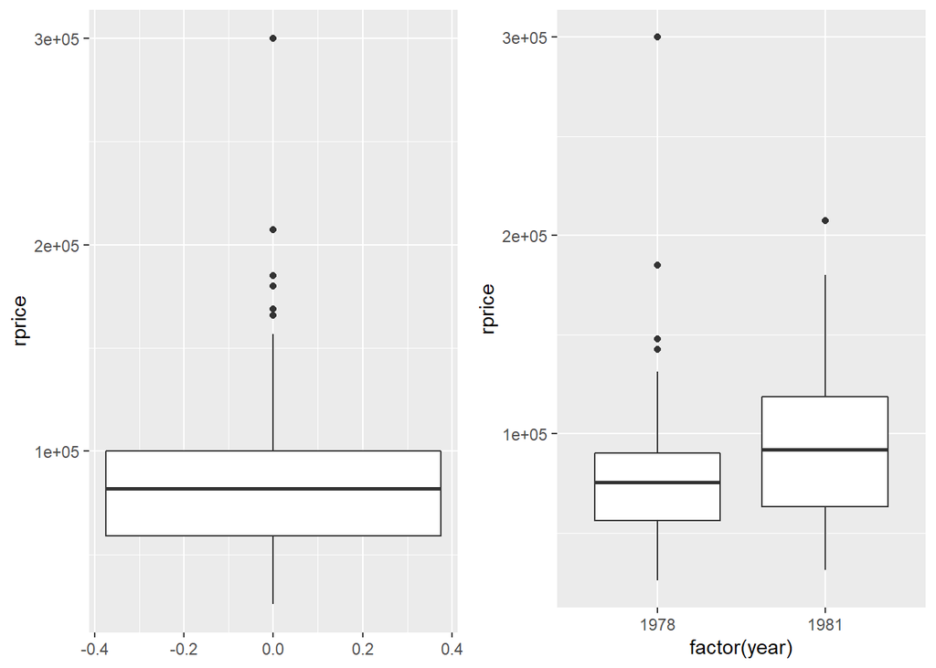

```r
library(ggplot2)
library(gridExtra)
grid.arrange(
  ggplot(data = PH)+
    aes(y = rprice)+
    geom_boxplot(),

  ggplot(data = PH)+
    aes(y = rprice, x = factor(year))+
    geom_boxplot(),

  ncol = 2)
```

#### 5. Analice la relacion entre la distancia del hogar al incinerador y el precio de venta a través de un grafico de dispersion, grafique la tendencia de ese grafico para cada una de las etapas

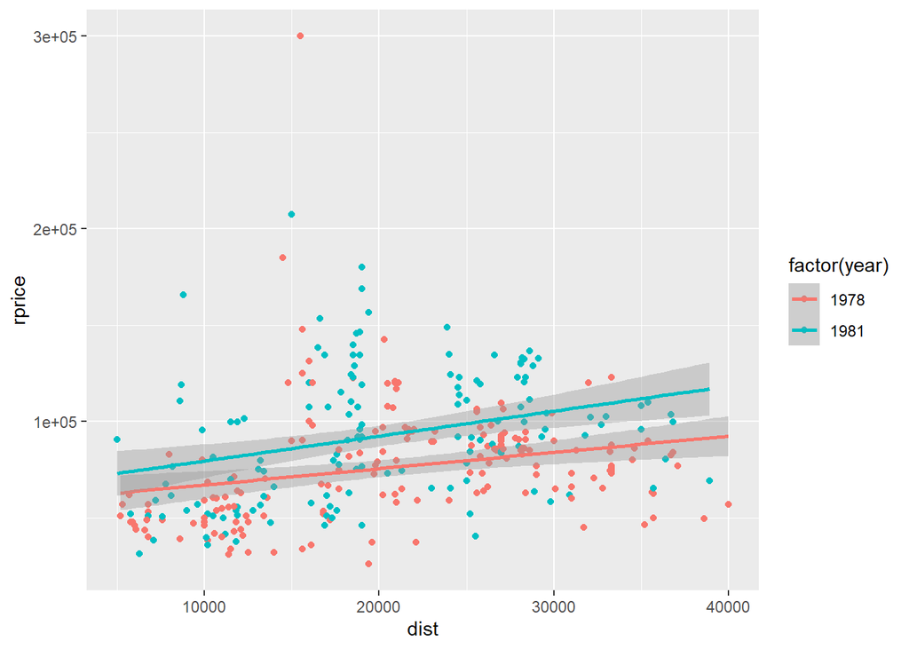

```r
ggplot(data = PH)+
    aes(y = rprice, x = dist, colour = factor(year))+
    geom_point()+
    geom_smooth(method = lm)
```

#### 6. Calcule la matriz de correlacion, que variables son redundantes, cuales retiraria?

```r
cor(PH[, -c(1, 11)])
```

```
##               age        cbd      intst       rooms        area       land
## age    1.00000000 -0.3902696 -0.3892428 -0.05119058 -0.04542196 -0.1123577
## cbd   -0.39026964  1.0000000  0.9873027  0.30409460  0.17350509  0.4018537
## intst -0.38924278  0.9873027  1.0000000  0.30127759  0.18698217  0.4231576
## rooms -0.05119058  0.3040946  0.3012776  1.00000000  0.53414462  0.1742279
## area  -0.04542196  0.1735051  0.1869822  0.53414462  1.00000000  0.1688850
## land  -0.11235767  0.4018537  0.4231576  0.17422790  0.16888500  1.0000000
## baths -0.35692676  0.3818874  0.3828795  0.60376614  0.66281541  0.2383748
## dist  -0.35017382  0.9593543  0.9165934  0.27358246  0.12838669  0.3318117
## wind  -0.30010948  0.6622869  0.7282356  0.32280696  0.25675522  0.4451204
##            baths       dist       wind
## age   -0.3569268 -0.3501738 -0.3001095
## cbd    0.3818874  0.9593543  0.6622869
## intst  0.3828795  0.9165934  0.7282356
## rooms  0.6037661  0.2735825  0.3228070
## area   0.6628154  0.1283867  0.2567552
## land   0.2383748  0.3318117  0.4451204
## baths  1.0000000  0.3451163  0.3825408
## dist   0.3451163  1.0000000  0.4896653
## wind   0.3825408  0.4896653  1.0000000
```

Se han descrito dos metodologias para demostrar el cambio en el efecto que tiene una desamenidad sobre el valor de un bien. En el primero de ellos se estiman dos regresiones (un modelo para cada una de las etapas de analisis) y se comparan sus coeficientes. La forma funcional del modelo a estimar es la siguiente:

$$logPrice_{t} = \hat{\beta_{0t}} + \hat{\beta_{1t}}age + \hat{\beta_{2t}}Age^{2} + \hat{\beta_{3t}}Area + \hat{\beta_{4t}}bath + \hat{\beta_{5t}}rooms + \hat{\beta_{6t}}land + \hat{\beta_{7t}}logDist + \hat{\beta_{8t}}intst + \hat{\beta_{9t}}intst^{2} + e$$

##### 7. De acuerdo a informacion anterior, realizar las transformaciones a las variables indicadas para cumplir con la forma funcional del modelo. Que diferencias obede una forma funcional al cuadrado con una funcon logartimica

```r
library(dplyr)
PH2 <- PH %>% select(year, age, area, baths, rooms, land, dist, intst, rprice) %>%
  mutate(logDist = log(dist),
         logPrice = log(rprice))
```

##### 8. Estimar el modelo descrito anteriormente para las ventas realizadas en el año 1978 y otro para las ventas del año 1981. Realice una comparacion de los resultados con respecto a sus signos y la significancia de los coeficientes.

```r
# modelo 78
model78 <- lm(data=PH2[which(PH2$year == 1978), ], logPrice ~ age + I(age^2) + area + baths + rooms + land + logDist + intst + I(intst^2))
summary(model78)
```

```
##
## Call:
## lm(formula = logPrice ~ age + I(age^2) + area + baths + rooms +
##     land + logDist + intst + I(intst^2), data = PH2[which(PH2$year ==
##     1978), ])
##
## Residuals:
##      Min       1Q   Median       3Q      Max
## -1.20450 -0.08218  0.01558  0.09674  0.63219
##
## Coefficients:
##               Estimate Std. Error t value Pr(>|t|)
## (Intercept)  9.542e+00  6.114e-01  15.607  < 2e-16 ***
## age         -8.546e-03  1.879e-03  -4.549 1.03e-05 ***
## I(age^2)     3.480e-05  1.087e-05   3.201  0.00163 **
## area         2.308e-04  3.562e-05   6.478 9.75e-10 ***
## baths        6.230e-02  3.564e-02   1.748  0.08224 .
## rooms        6.127e-02  2.192e-02   2.796  0.00578 **
## land         7.954e-07  3.438e-07   2.314  0.02189 *
## logDist      7.611e-02  6.577e-02   1.157  0.24883
## intst        1.319e-06  9.453e-06   0.140  0.88919
## I(intst^2)  -1.619e-10  2.368e-10  -0.684  0.49512
## ---
## Signif. codes:  0 '***' 0.001 '**' 0.01 '*' 0.05 '.' 0.1 ' ' 1
##
## Residual standard error: 0.2076 on 169 degrees of freedom
## Multiple R-squared:  0.6963, Adjusted R-squared:  0.6801
## F-statistic: 43.05 on 9 and 169 DF,  p-value: < 2.2e-16
```

```r
# modelo 81
model81 <- lm(data=PH2[which(PH2$year == 1981), ], logPrice ~ age + I(age^2) + area + baths + rooms + land + logDist + intst + I(intst^2))
summary(model81)
```

```
##
## Call:
## lm(formula = logPrice ~ age + I(age^2) + area + baths + rooms +
##     land + logDist + intst + I(intst^2), data = PH2[which(PH2$year ==
##     1981), ])
##
## Residuals:
##      Min       1Q   Median       3Q      Max
## -0.72143 -0.09949  0.00231  0.09878  0.62556
##
## Coefficients:
##               Estimate Std. Error t value Pr(>|t|)
## (Intercept)  8.750e+00  6.394e-01  13.686  < 2e-16 ***
## age         -7.080e-03  2.823e-03  -2.508 0.013360 *
## I(age^2)     3.958e-05  2.507e-05   1.579 0.116751
## area         1.390e-04  3.346e-05   4.153 5.85e-05 ***
## baths        1.547e-01  4.187e-02   3.694 0.000322 ***
## rooms        3.564e-02  2.985e-02   1.194 0.234623
## land         7.204e-07  1.579e-06   0.456 0.649051
## logDist      1.720e-01  6.706e-02   2.565 0.011431 *
## intst        1.941e-05  1.243e-05   1.561 0.120893
## I(intst^2)  -7.897e-10  3.025e-10  -2.610 0.010088 *
## ---
## Signif. codes:  0 '***' 0.001 '**' 0.01 '*' 0.05 '.' 0.1 ' ' 1
##
## Residual standard error: 0.1968 on 132 degrees of freedom
## Multiple R-squared:  0.7615, Adjusted R-squared:  0.7452
## F-statistic: 46.82 on 9 and 132 DF,  p-value: < 2.2e-16
```

- Todas las variables tienen el signo esperado
- Dentro de las caacteristicas de la vivienda age 2, rooms and land no fueron significativas
- En este periodo la distancia hacia la zona del incinerador si fue significativa con el signo esperado

#### 9. Graficar el efecto de la distancia en pies al incinerador sobre el precio de las casas (asuma el promedio para el resto de variables)

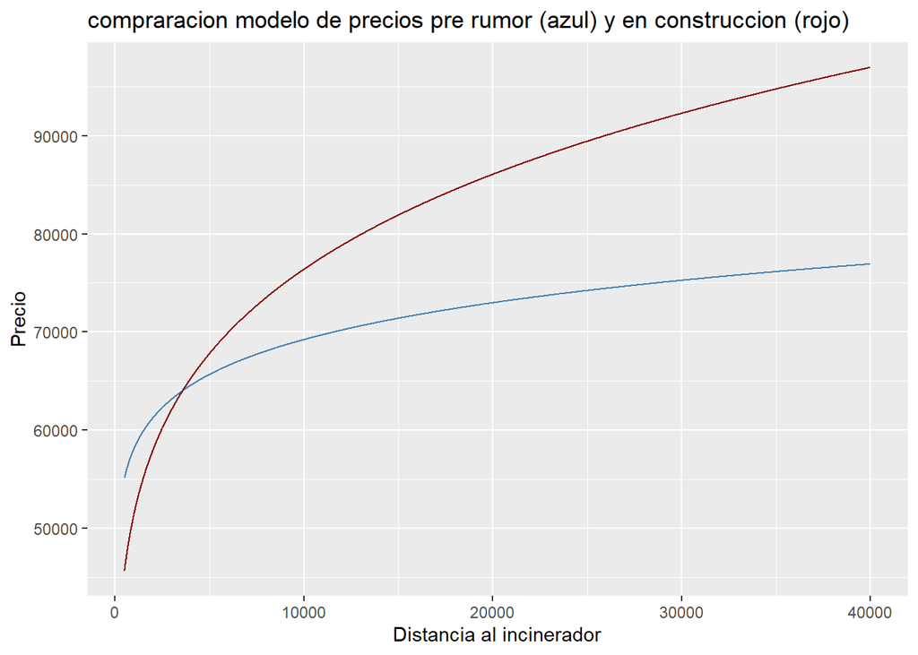

```r
Predicciones <- data.frame(dist = seq(500, 40000),
                           age = mean(PH2$age),
                           area = mean(PH2$area),
                           baths = mean(PH2$baths),
                           rooms = mean(PH2$rooms),
                           land = mean(PH2$land),
                           intst = mean(PH2$intst)) %>%
  mutate(logDist = log(dist))
predicciones78 <- predict(model78, Predicciones)
predicciones81 <- predict(model81, Predicciones)
Predicciones$pred78 <- exp(predicciones78)
Predicciones$pred81 <- exp(predicciones81)


ggplot(Predicciones)+
  aes(x = dist)+
  geom_line(aes(y = pred78), colour = "steelblue")+
  geom_line(aes(y = pred81), colour = "darkred")+
  ggtitle("compraracion modelo de precios pre rumor (azul) y en construccion (rojo)")+
  ylab("Precio")+
  xlab("Distancia al incinerador")
```

- A partir de los 10 mil pies se empieza a agrandar el efecto de la diferencia entre la distancia al incinerador (genera casas premiums)
- Por otro lado al comparar mas o menos 500 pies, se observa que la demanda cae porque el precio antes del incinerador era mas alto que el precio expost

#### 10. Calcule el precio implicito en el cambio para las dos etapas evaluadas a partir de los modelos

```r
# impacto 78
betaLodDist78 <- 0.07611
mediaPrecio78 <- mean(PH2[which(PH2$year == 1978), 9])
mediaDist78 <- mean(PH2[which(PH2$year == 1978), 7])
PrecioPie78 <- (mediaPrecio78/mediaDist78)*betaLodDist78
```

```r
# impacto 81
betaLodDist81 <- 0.1720
mediaPrecio81 <- mean(PH2[which(PH2$year == 1981), 9])
mediaDist81 <- mean(PH2[which(PH2$year == 1981), 7])
PrecioPie81 <- (mediaPrecio81/mediaDist81)*betaLodDist81
```

```r
# Impacto
PrecioPie78 - PrecioPie81
```

```
## [1] -0.5173601
```

En promedio, una vivienda perdio 0.52 US en su precio de venta por cada pie de cercania al incinerador al momento de su construccion.

El segundo metodo consiste en estimar un solo modelo incorporando la variable de etapa dentro del modelo. Asi mismo, se debe incorporar un termino denominado **interaccion** el cual modela el efecto conjunto de dos variables. Para este caso la interaccion será entre las variables distancia al incinerador y año.

#### 11. Graficar el efecto de la interaccion entre etapa y distancia al incinerador vs precio

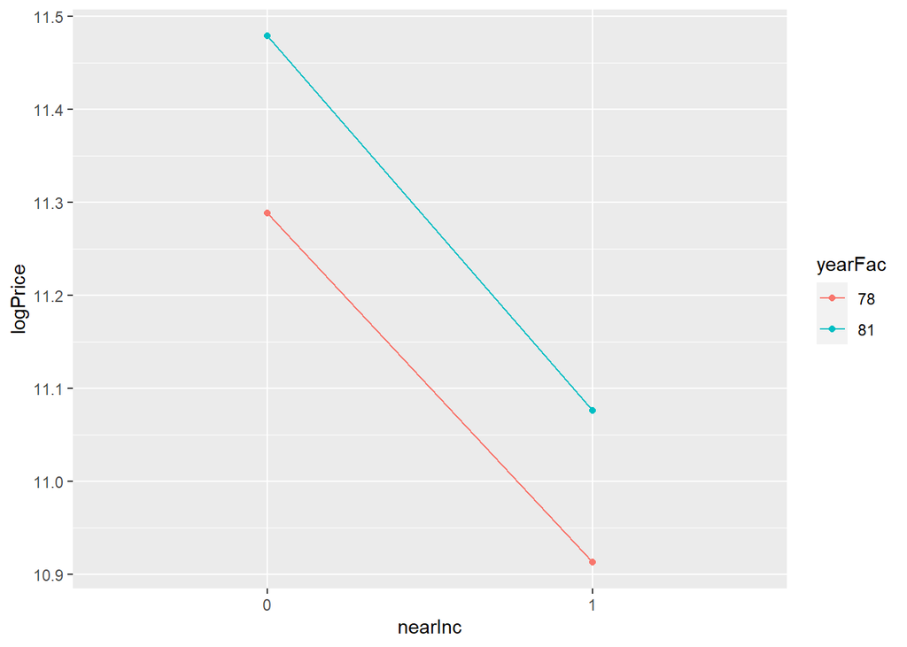

```r
PH2$nearInc <- as.factor(ifelse(PH2$logDist <= 9.655026, 1, 0))
PH2$yearFac <- as.factor(ifelse(PH2$year == 1978, 78, 81))
PH2 %>%
  group_by(nearInc, yearFac) %>%
  summarize(logPrice = mean(logPrice)) %>%
  ggplot()+
  aes(x = nearInc, y = logPrice, colour = yearFac)+
  geom_line(aes(group = yearFac))+
  geom_point()
```

- No parece tener efecto ya que la diferencia entre los que estan lejos del incinerador en ambos periodas es igual para el segundo año
- tiene que ver con las trasnformaciones del modelo.

#### 12. Estimar el modelo con la interaccion

```r
ModelComp <- lm(data = PH2,
                logPrice ~ age + I(age^2) + area + baths + rooms + land + logDist + intst + I(intst^2) + yearFac + logDist*yearFac)
summary(ModelComp)
```

```
##
## Call:
## lm(formula = logPrice ~ age + I(age^2) + area + baths + rooms +
##     land + logDist + intst + I(intst^2) + yearFac + logDist *
##     yearFac, data = PH2)
##
## Residuals:
##      Min       1Q   Median       3Q      Max
## -1.24055 -0.08708  0.01300  0.10165  0.69591
##
## Coefficients:
##                     Estimate Std. Error t value Pr(>|t|)
## (Intercept)        9.226e+00  4.892e-01  18.857  < 2e-16 ***
## age               -7.400e-03  1.395e-03  -5.306 2.14e-07 ***
## I(age^2)           3.030e-05  8.578e-06   3.532 0.000475 ***
## area               1.801e-04  2.400e-05   7.505 6.62e-13 ***
## baths              1.048e-01  2.667e-02   3.929 0.000105 ***
## rooms              4.995e-02  1.710e-02   2.921 0.003741 **
## land               7.938e-07  3.280e-07   2.420 0.016106 *
## logDist            1.114e-01  5.143e-02   2.166 0.031106 *
## intst              9.241e-06  6.906e-06   1.338 0.181839
## I(intst^2)        -4.369e-10  1.778e-10  -2.457 0.014553 *
## yearFac81         -1.855e-01  4.876e-01  -0.380 0.703926
## logDist:yearFac81  3.000e-02  4.959e-02   0.605 0.545578
## ---
## Signif. codes:  0 '***' 0.001 '**' 0.01 '*' 0.05 '.' 0.1 ' ' 1
##
## Residual standard error: 0.2032 on 309 degrees of freedom
## Multiple R-squared:  0.7351, Adjusted R-squared:  0.7257
## F-statistic: 77.96 on 11 and 309 DF,  p-value: < 2.2e-16
```

- Signos coinciden con lo esperado
- No significativo la iteraccion, puede ser porque este modelo supone el resto de factores constantes a traves del tiempo
- Nos quedamos con el primer analisis

#### 13. Calcule el precio implicito en el cambio para las dos etapas evaluadas a partir del segundo modelo

```r
betaLodDist <- 0.03
mediaPrecio <- mean(PH2$rprice)
mediaDist <- mean(PH2$dist)
PrecioPie <- (mediaPrecio/mediaDist)*betaLodDist
```